# Raport z pracy domowej nr.2

Katarzyna Mamla

31 03 2022

# Istota zadania

W ramach pracy domowej nr.2 należało przygotować wizualizację z wykorzystaniem pakietu`ggplot2`.  
Wizualizacja ta miała być wykonana na podstawie dostępnej już w prasie, telewizji czy internecie grafiki, opublikowanej w ciągu ostatnich 2 tygodni od daty zamieszczenia zadania tj. od dnia 23.03.2022.

## Wizualizacja

Wizualizacją, którą zdecydowałam się poprawić jest:

[figure not shown]

Pochodzi ona z artykułu na temat wydatków rządów na zdrowie w 2019 i 2020 roku umieszczonego na stronie: [ec.europa.eu/eurostat](https://ec.europa.eu/eurostat/en/web/products-eurostat-news/-/ddn-20220311-1)

## Ramka danych i kod

W celu stworzenia własnej, zmodyfikowanej grafiki pobrałam ramkę danych dostępną na [ec.europa.eu/eurostat/databrowser](https://ec.europa.eu/eurostat/databrowser/view/GOV_10A_EXP__custom_2243551/bookmark/table?lang=en&bookmarkId=8df11907-86e8-4f5b-a62e-a7d09828e303)

```
##                 DATAFLOW       LAST.UPDATE freq   unit sector cofog99 na_item
## 1 ESTAT:GOV_10A_EXP(1.0) 28/02/22 11:00:00    A PC_GDP    S13    GF07      TE
## 2 ESTAT:GOV_10A_EXP(1.0) 28/02/22 11:00:00    A PC_GDP    S13    GF07      TE
## 3 ESTAT:GOV_10A_EXP(1.0) 28/02/22 11:00:00    A PC_GDP    S13    GF07      TE
## 4 ESTAT:GOV_10A_EXP(1.0) 28/02/22 11:00:00    A PC_GDP    S13    GF07      TE
## 5 ESTAT:GOV_10A_EXP(1.0) 28/02/22 11:00:00    A PC_GDP    S13    GF07      TE
## 6 ESTAT:GOV_10A_EXP(1.0) 28/02/22 11:00:00    A PC_GDP    S13    GF07      TE
##   geo TIME_PERIOD OBS_VALUE OBS_FLAG
## 1  AT        2019       8.3
## 2  AT        2020       9.2
## 3  BE        2019       7.5
## 4  BE        2020       8.8
## 5  BG        2019       4.6
## 6  BG        2020       5.9
```

Nastepnie napisałam kod w którym sprowadziłam pobraną ramkę do postaci umożliwiającej stworzenie wizualizacji.

```
##   TIME_PERIOD OBS_VALUE       geo
## 1        2019       7.0        EU
## 2        2020       8.0        EU
## 3        2019       7.1 Euro area
## 4        2020       8.2 Euro area
## 5        2019       8.3   Austria
## 6        2020       9.2   Austria
```

Kod:

```r
library(dplyr)


# install.packages('eurostat')
# install.packages("countrycode")

library(eurostat)
library(countrycode)
library(ggplot2)

df <- read.csv("gov.table.gz")
d <-df %>%
  select(- c(1:7, 11)) %>%
  transmute(TIME_PERIOD, OBS_VALUE,
            geo = countrycode(sourcevar = df$geo, "eurostat", "country.name",
                              custom_match = c('EA19'= 'Euro area',
                                               'EU27_2020'='EU'))) %>%
  arrange(match(geo,c("EU", "Euro area")))
visual <-d %>%
  ggplot(aes(x =geo, y =OBS_VALUE, fill= as.factor(TIME_PERIOD))) +
  geom_bar( position= position_dodge(width = 0.7),stat ='identity',width = 0.8) +
  labs(title = "General government expenditure on health",
       x= NULL,y='% of GDP', fill=NULL,
       subtitle = "in % of GDP, 2019 and 2020",
       caption = "Data: https://ec.europa.eu/eurostat/en/web/products-eurostat-news/-/ddn-20220311-1")+
  scale_y_continuous(expand = c(0, 0), limits = c(0, 10))+
  scale_fill_brewer(palette = "Paired", direction = -1)+ theme_bw()+
  theme(
    axis.text.x=element_text(angle=20, size=8),
    axis.title.y=element_text( face='bold', size=14),
    plot.title = element_text(size = 20, face='bold'),
    legend.text = element_text(size = 12),
    legend.background = element_rect(linetype = 1, size = 0.5, colour = 1),
    legend.position = 'top'
    )
```

Wykonując powyższy kod otrzymuję gotową wizualizację:

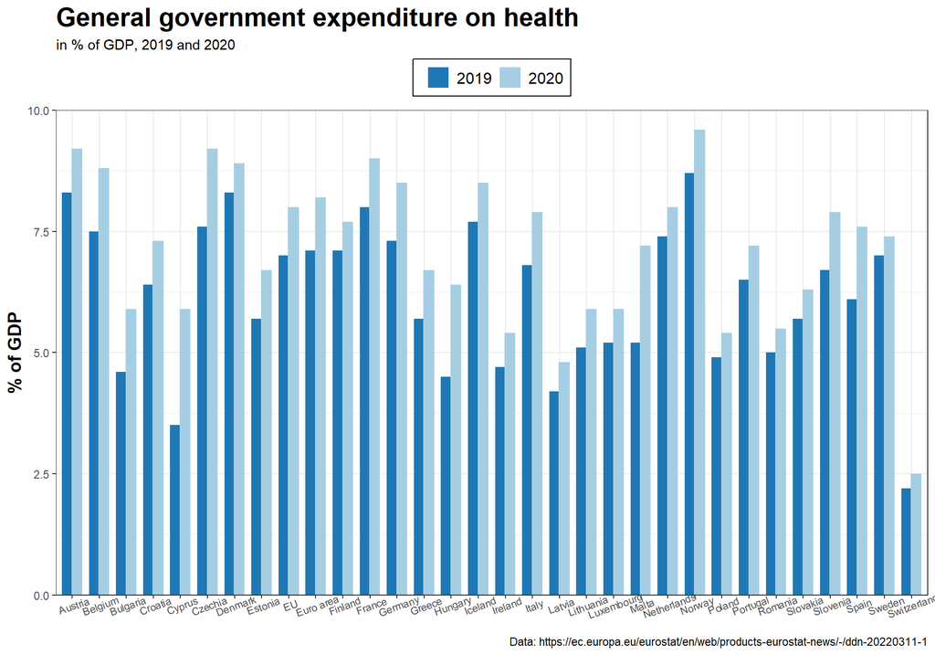

## Uzasadnienie

Wprowadzone zmiany:

- Elementami wykresu, które zdecydowałam się poprawić były punkty z danymi z 2019 roku zamieszczone na kolumnach z danymi z roku 2020.  
  Na pierwszy rzut oka nie wiadomo co te pojedyńcze punkty oznaczają.  
  W tym celu, na swoim wykresie, do każdego kraju stworzyłam dwie kolumny z oddzielnymi procentami GDP w roku 2019 i 2020,  
  co poprawiło przyjrzystość wykresu i ułatwiło porównywanie danych z tych dwóch okresów.
- Kolejnymi elementami, których się pozbyłam, były niepotrzebne przerwy pomiędzy słupkami po prawej i lewej stronie wykrsu. Zrezygonowałam też z kolorowego tła i dodatkowej grafiki.